# Systolic blood pressure

# 1 Description of DataSchema variable

The description of harmonised variable is the following:

- Short name: `sbp`
- Variable label: `Systolic blood pressure of participant at each wave`
- Domain: `Physical measures`
- Value type: `Continuous`
- Category missings:

| **Code** | **Category Label** |
| --- | --- |
| 991 | CAPI/interviewer error |
| 992 | Impute |
| 993 | Disable to measure |
| 994 | Not attempt/not done |
| 995 | Does not answer |
| 996 | Not applicable |
| 997 | Refuse |
| 998 | Do not know |
| 999 | Missing |

- Comments: `Means of all sistolic blood pressure measures.`

# 2 Data process

## 2.1 England

### 2.1.1 Wave 1

There is no variable.

### 2.1.2 Wave 2

#### 2.1.2.1 Study-specific variable description

The study-specific variable elected to be harmonised is:

- Name: `sys1`
- Label: `BP: 1st systolic reading (mmHg)`
- Type of variable: `countinous`
- Missings
  - `-9 = No answer/Refusal`
  - `-8 = Dont know`
  - `-3 = Error reading`
  - `-2 = No reading obtained`
  - `-1 = Not Applicable`
- Name: `sys2`
- Label: `BP: 2nd systolic reading (mmHg)`
- Type of variable: `countinous`
- Missings
  - `-9 = No answer/Refusal`
  - `-8 = Dont know`
  - `-3 = Error reading`
  - `-2 = No reading obtained`
  - `-1 = Not Applicable`
- Name: `sys3`
- Label: `BP: 3rd systolic reading (mmHg)`
- Type of variable: `countinous`
- Missings
  - `-9 = No answer/Refusal`
  - `-8 = Dont know`
  - `-3 = Error reading`
  - `-2 = No reading obtained`
  - `-1 = Not Applicable`

```
## $summary
##    Min. 1st Qu.  Median    Mean 3rd Qu.    Max.
##    72.0   124.0   137.0   138.3   150.0   243.0
##
## $values_table
##            No-missings -9 -8 -3   -2    -1 NA
## Frequency      7558.00  0  0  0 84.0 24.00  0
## Percentage       98.59  0  0  0  1.1  0.31  0
##
## $n_table
##      Sample size Missing values
## [1,]        7666            108
```

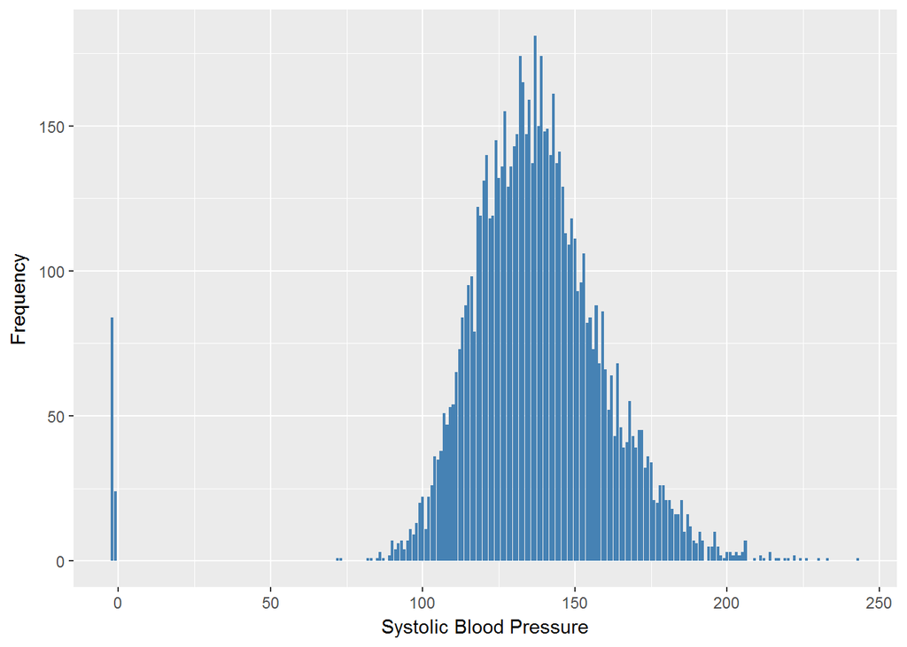

```
## $summary
##    Min. 1st Qu.  Median    Mean 3rd Qu.    Max.
##    62.0   122.0   134.0   135.9   147.0   256.0
##
## $values_table
##            No-missings -9 -8 -3     -2    -1 NA
## Frequency      7524.00  0  0  0 118.00 24.00  0
## Percentage       98.15  0  0  0   1.54  0.31  0
##
## $n_table
##      Sample size Missing values
## [1,]        7666            142
```

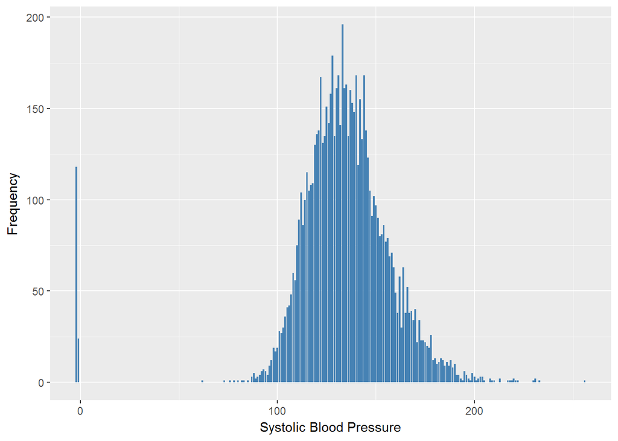

```
## $summary
##    Min. 1st Qu.  Median    Mean 3rd Qu.    Max.
##    75.0   121.0   133.0   134.8   146.0   262.0
##
## $values_table
##            No-missings -9 -8 -3  -2    -1 NA
## Frequency      7489.00  0  0  0 153 24.00  0
## Percentage       97.69  0  0  0   2  0.31  0
##
## $n_table
##      Sample size Missing values
## [1,]        7666            177
```

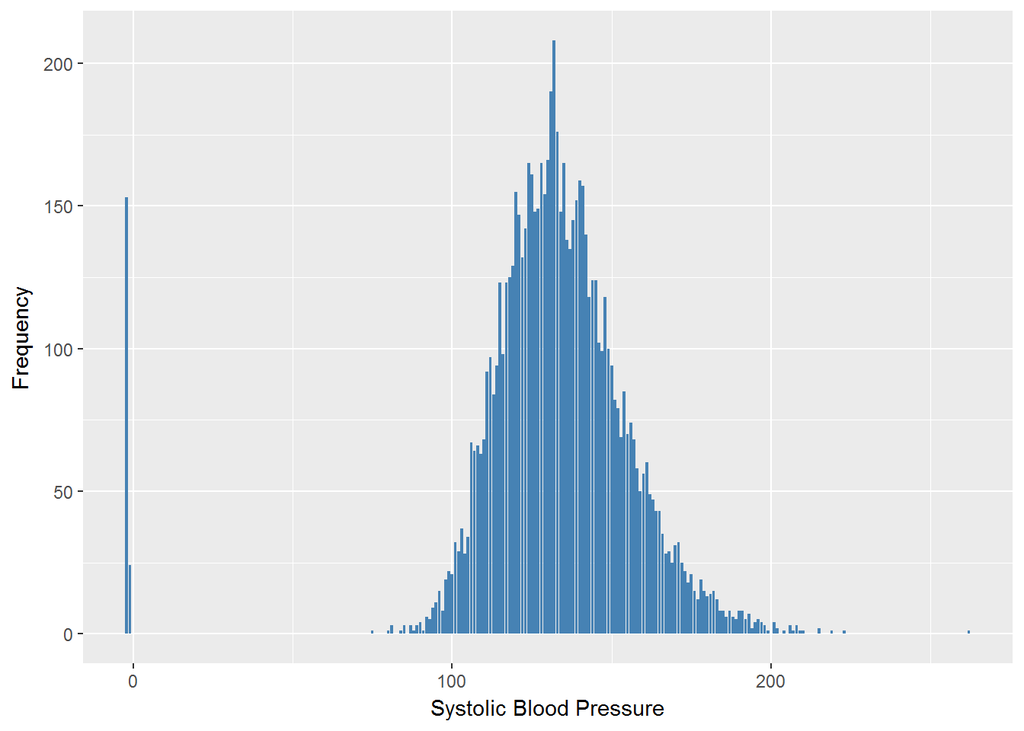

#### 2.1.2.2 Harmonisation algorithm

The harmonized variable is the mean value between the first, second and third measurement of the study-specific variables, but the missing values have to be recoded as follows:

- `recode -9 "No answer/Refusal" into 995`
- `recode -8 "Dont know" into 998`
- `recode -3 "Error reading" into 991`
- `recode -2 "No reading obtained" into 999`
- `recode -1 "Not Applicable" into 996`
- `NA into 999`

**R script:**

```r
ELSA_w2_sbp$mean_sbp <- apply(X = ELSA_w2_sbp[, c(2, 3, 4)], MARGIN = 1, FUN = mean)

### -2 only in the first one
id2_only01 <- which(ELSA_w2_sbp$sys1 == -2 & ELSA_w2_sbp$sys2 != -2 & ELSA_w2_sbp$sys3 !=
    -2)

ELSA_w2_sbp$mean_sbp[id2_only01] <- apply(X = ELSA_w2_sbp[id2_only01, c(3, 4)],
    MARGIN = 1, FUN = mean)

### -2 only in the third one
id2_only03 <- which(ELSA_w2_sbp$sys1 != -2 & ELSA_w2_sbp$sys2 != -2 & ELSA_w2_sbp$sys3 ==
    -2)

ELSA_w2_sbp$mean_sbp[id2_only03] <- apply(X = ELSA_w2_sbp[id2_only03, c(2, 3)],
    MARGIN = 1, FUN = mean)

### -2 in the first and second one
id2_01_02 <- which(ELSA_w2_sbp$sys1 == -2 & ELSA_w2_sbp$sys2 == -2 & ELSA_w2_sbp$sys3 !=
    -2)

ELSA_w2_sbp$mean_sbp[id2_01_02] <- ELSA_w2_sbp$sys3[id2_01_02]

### -2 in the first and third one
id2_01_03 <- which(ELSA_w2_sbp$sys1 == -2 & ELSA_w2_sbp$sys2 == -2 & ELSA_w2_sbp$sys3 !=
    -2)

ELSA_w2_sbp$mean_sbp[id2_01_03] <- ELSA_w2_sbp$sys2[id2_01_03]

### -2 in the second and third one
id2_02_03 <- which(ELSA_w2_sbp$sys1 != -2 & ELSA_w2_sbp$sys2 == -2 & ELSA_w2_sbp$sys3 ==
    -2)

ELSA_w2_sbp$mean_sbp[id2_02_03] <- ELSA_w2_sbp$sys1[id2_02_03]


ELSA_ds_w2 <- tibble(id = ELSA_w2_sbp$id)
ELSA_ds_w2$sbp <- car::recode(ELSA_w2_sbp$mean_sbp, "NA=999; -9=995; -8=998; -3=991; -2=999; -1=996")
ELSA_ds_w2$sbp <- labelled(ELSA_ds_w2$sbp, labels = c(Missing = 999, `Do not know` = 998,
    Refuse = 997, `Not applicable` = 996, `Does not answer` = 995, `Not attempt not done` = 994,
    `Disable to measure` = 993, Impute = 992, `CAPI interviewer error` = 991))
```

#### 2.1.2.3 Statistics of the new harmonised variable

```
## $summary
##    Min. 1st Qu.  Median    Mean 3rd Qu.    Max.
##   29.67  123.00  134.67  136.36  147.67  244.67
##
## $values_table
##            No-missings 991 992 993 994 995   996 997 998   999 NA
## Frequency      7561.00   0   0   0   0   0 24.00   0   0 81.00  0
## Percentage       98.63   0   0   0   0   0  0.31   0   0  1.06  0
##
## $n_table
##      Sample size Missing values
## [1,]        7666            105
```

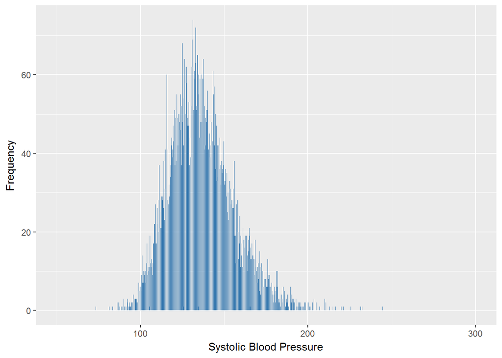

#### 2.1.2.4 Validation

### 2.1.3 Wave 3

There is no variable.

### 2.1.4 Wave 4

#### 2.1.4.1 Study-specific variable description

The study-specific variable elected to be harmonised is:

- Name: `sys1`
- Label: `BP: 1st systolic reading (mmHg)`
- Type of variable: `countinous`
- Missings
  - `-1 = Not Applicable`
  - `999 = Reading not obtained`
- Name: `sys2`
- Label: `BP: 2nd systolic reading (mmHg)`
- Type of variable: `countinous`
- Missings
  - `-1 = Not Applicable`
  - `999 = Reading not obtained`
- Name: `sys3`
- Label: `BP: 3rd systolic reading (mmHg)`
- Type of variable: `countinous`
- Missings
  - `-1 = Not Applicable`
  - `999 = Reading not obtained`

```
## $summary
##    Min. 1st Qu.  Median    Mean 3rd Qu.    Max.
##    64.0   122.0   134.0   135.2   147.0   240.0
##
## $values_table
##            No-missings    -1   999 NA
## Frequency      8532.00 37.00 74.00  0
## Percentage       98.72  0.43  0.86  0
##
## $n_table
##      Sample size Missing values
## [1,]        8643            111
```

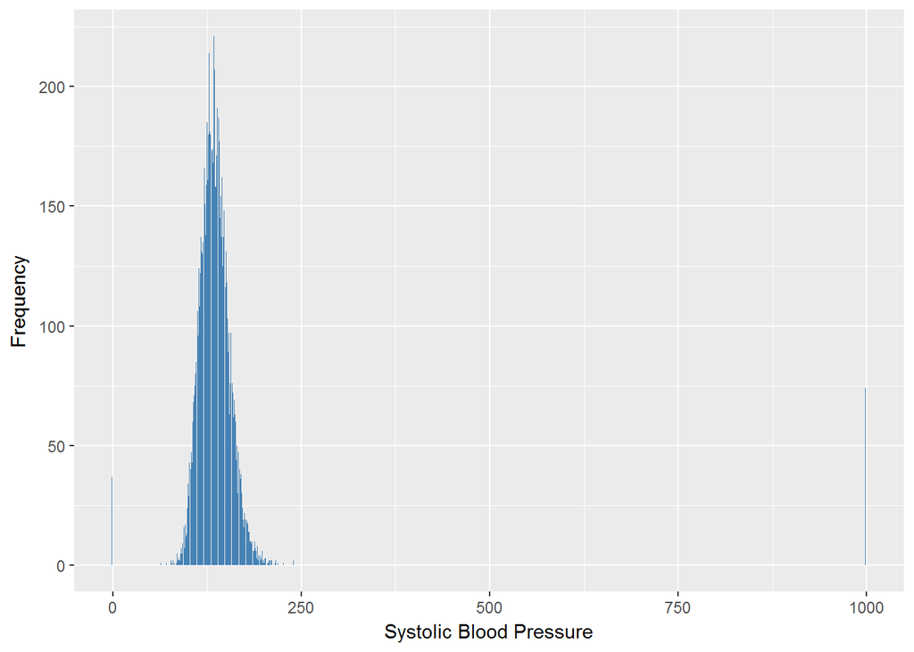

```
## $summary
##    Min. 1st Qu.  Median    Mean 3rd Qu.    Max.
##    64.0   120.0   132.0   132.9   144.0   227.0
##
## $values_table
##            No-missings    -1    999 NA
## Frequency      8493.00 37.00 113.00  0
## Percentage       98.26  0.43   1.31  0
##
## $n_table
##      Sample size Missing values
## [1,]        8643            150
```

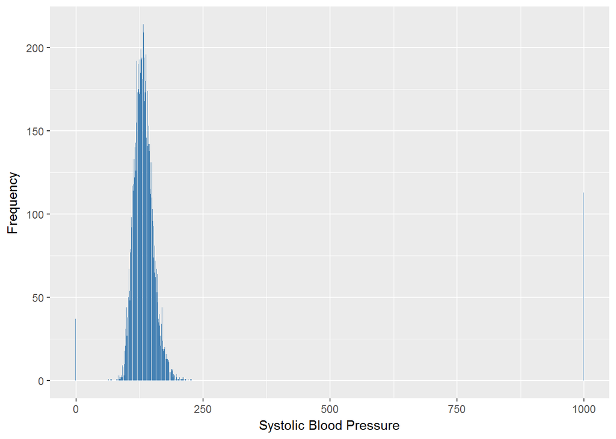

```
## $summary
##    Min. 1st Qu.  Median    Mean 3rd Qu.    Max.
##    57.0   120.0   131.0   132.2   143.0   226.0
##
## $values_table
##            No-missings    -1    999 NA
## Frequency      8439.00 37.00 167.00  0
## Percentage       97.64  0.43   1.93  0
##
## $n_table
##      Sample size Missing values
## [1,]        8643            204
```

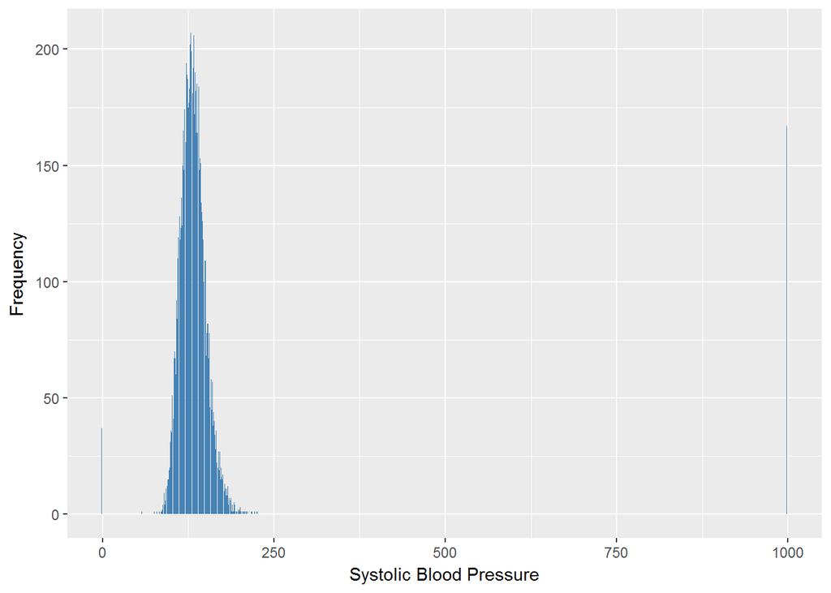

#### 2.1.4.2 Harmonisation algorithm

The harmonized variable is the mean value between the first, second and third measurement of the study-specific variables, but the missing values have to be recoded as follows:

- `keep "Reading not obtained" into 999`
- `recode -1 "Not Applicable" into 996`
- `NA into 999`

**R script:**

```r
ELSA_w4_sbp$sys1 <- car::recode(ELSA_w4_sbp$sys1, "999=-2")
ELSA_w4_sbp$sys2 <- car::recode(ELSA_w4_sbp$sys2, "999=-2")
ELSA_w4_sbp$sys3 <- car::recode(ELSA_w4_sbp$sys3, "999=-2")

ELSA_w4_sbp$mean_sbp <- apply(X = ELSA_w4_sbp[, c(2, 3, 4)], MARGIN = 1, FUN = mean)

### -2 only in the first one
id2_only01 <- which(ELSA_w4_sbp$sys1 == -2 & ELSA_w4_sbp$sys2 != -2 & ELSA_w4_sbp$sys3 !=
    -2)

ELSA_w4_sbp$mean_sbp[id2_only01] <- apply(X = ELSA_w4_sbp[id2_only01, c(3, 4)],
    MARGIN = 1, FUN = mean)

### -2 only in the second one
id2_only02 <- which(ELSA_w4_sbp$sys1 != -2 & ELSA_w4_sbp$sys2 == -2 & ELSA_w4_sbp$sys3 !=
    -2)

ELSA_w4_sbp$mean_sbp[id2_only02] <- apply(X = ELSA_w4_sbp[id2_only02, c(2, 4)],
    MARGIN = 1, FUN = mean)

### -2 only in the third one
id2_only03 <- which(ELSA_w4_sbp$sys1 != -2 & ELSA_w4_sbp$sys2 != -2 & ELSA_w4_sbp$sys3 ==
    -2)

ELSA_w4_sbp$mean_sbp[id2_only03] <- apply(X = ELSA_w4_sbp[id2_only03, c(2, 3)],
    MARGIN = 1, FUN = mean)

### -2 in the first and second one
id2_01_02 <- which(ELSA_w4_sbp$sys1 == -2 & ELSA_w4_sbp$sys2 == -2 & ELSA_w4_sbp$sys3 !=
    -2)

ELSA_w4_sbp$mean_sbp[id2_01_02] <- ELSA_w4_sbp$sys3[id2_01_02]

### -2 in the first and third one
id2_01_03 <- which(ELSA_w4_sbp$sys1 == -2 & ELSA_w4_sbp$sys2 == -2 & ELSA_w4_sbp$sys3 !=
    -2)

ELSA_w4_sbp$mean_sbp[id2_01_03] <- ELSA_w4_sbp$sys2[id2_01_03]

### -2 in the second and third one
id2_02_03 <- which(ELSA_w4_sbp$sys1 != -2 & ELSA_w4_sbp$sys2 == -2 & ELSA_w4_sbp$sys3 ==
    -2)

ELSA_w4_sbp$mean_sbp[id2_02_03] <- ELSA_w4_sbp$sys1[id2_02_03]


ELSA_ds_w4 <- tibble(id = ELSA_w4_sbp$id)
ELSA_ds_w4$sbp <- car::recode(ELSA_w4_sbp$mean_sbp, "NA=999; -2=999; -1=996")
ELSA_ds_w4$sbp <- labelled(ELSA_ds_w4$sbp, labels = c(Missing = 999, `Do not know` = 998,
    Refuse = 997, `Not applicable` = 996, `Does not answer` = 995, `Not attempt not done` = 994,
    `Disable to measure` = 993, Impute = 992, `CAPI interviewer error` = 991))
```

#### 2.1.4.3 Statistics of the new harmonised variable

```
## $summary
##    Min. 1st Qu.  Median    Mean 3rd Qu.    Max.
##   81.67  121.00  132.33  133.51  144.33  225.67
##
## $values_table
##            No-missings 991 992 993 994 995   996 997 998   999 NA
## Frequency      8533.00   0   0   0   0   0 37.00   0   0 73.00  0
## Percentage       98.73   0   0   0   0   0  0.43   0   0  0.84  0
##
## $n_table
##      Sample size Missing values
## [1,]        8643            110
```

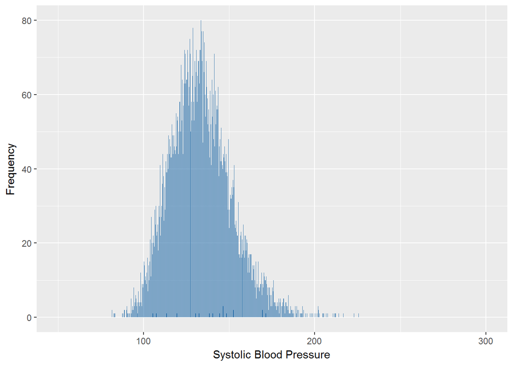

#### 2.1.4.4 Validation

### 2.1.5 Wave 5

There is no variable.

### 2.1.6 Wave 6

#### 2.1.6.1 Study-specific variable description

The study-specific variable elected to be harmonised is:

- Name: `sys1`
- Label: `BP: 1st systolic reading (mmHg)`
- Type of variable: `countinous`
- Missings
  - `-1 = Not Applicable`
  - `999 = Reading not obtained`
- Name: `sys2`
- Label: `BP: 2nd systolic reading (mmHg)`
- Type of variable: `countinous`
- Missings
  - `-1 = Not Applicable`
  - `999 = Reading not obtained`
- Name: `sys3`
- Label: `BP: 3rd systolic reading (mmHg)`
- Type of variable: `countinous`
- Missings
  - `-1 = Not Applicable`
  - `999 = Reading not obtained`

```
## $summary
##    Min. 1st Qu.  Median    Mean 3rd Qu.    Max.
##    57.0   121.0   133.0   134.2   145.0   235.0
##
## $values_table
##            No-missings    -1   999 NA
## Frequency      7974.00 25.00 55.00  0
## Percentage       99.01  0.31  0.68  0
##
## $n_table
##      Sample size Missing values
## [1,]        8054             80
```

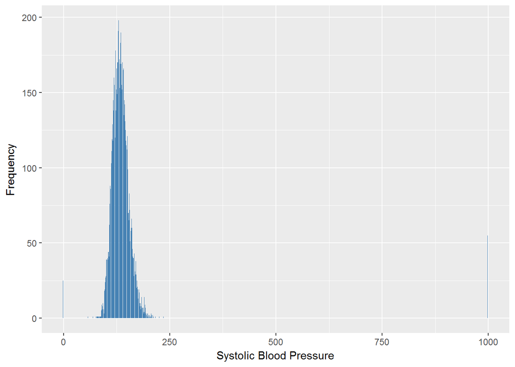

```
## $summary
##    Min. 1st Qu.  Median    Mean 3rd Qu.    Max.
##    76.0   120.0   131.0   132.4   143.0   223.0
##
## $values_table
##            No-missings    -1   999 NA
## Frequency      7930.00 25.00 99.00  0
## Percentage       98.46  0.31  1.23  0
##
## $n_table
##      Sample size Missing values
## [1,]        8054            124
```

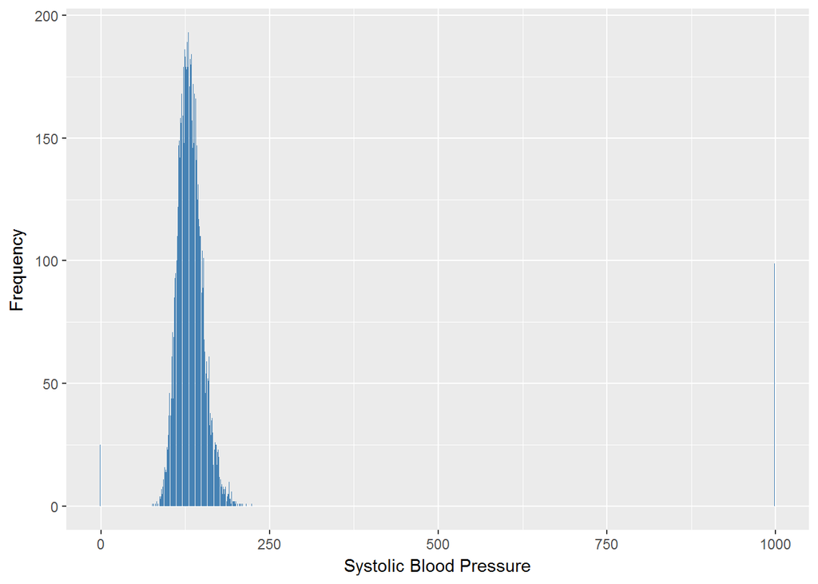

```
## $summary
##    Min. 1st Qu.  Median    Mean 3rd Qu.    Max.
##    77.0   119.0   130.0   131.7   142.0   225.0
##
## $values_table
##            No-missings    -1    999 NA
## Frequency      7891.00 25.00 138.00  0
## Percentage       97.98  0.31   1.71  0
##
## $n_table
##      Sample size Missing values
## [1,]        8054            163
```

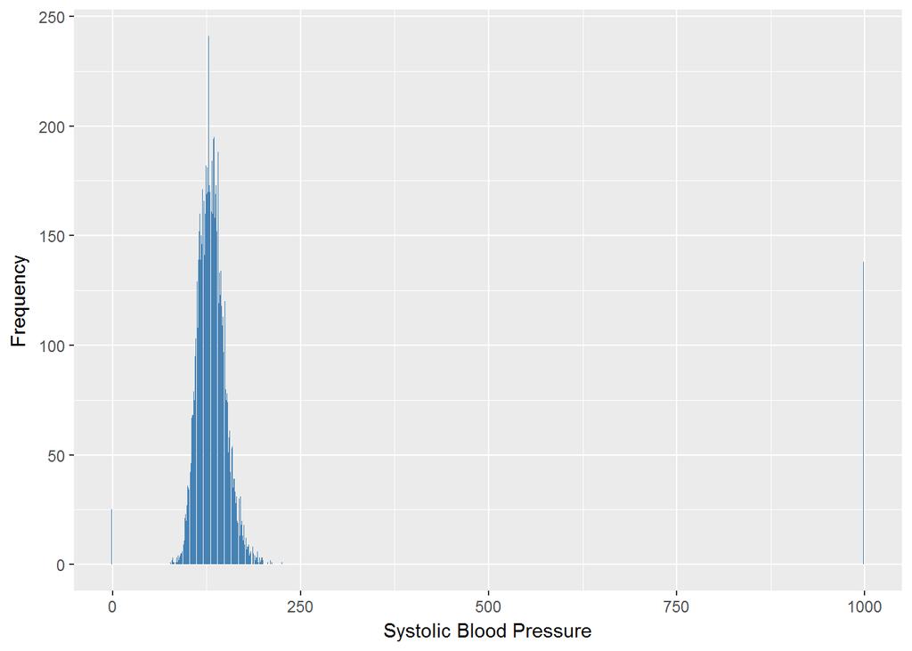

#### 2.1.6.2 Harmonisation algorithm

The harmonized variable is the mean value between the first, second and third measurement of the study-specific variables, but the missing values have to be recoded as follows:

- `keep "Reading not obtained" into 999`
- `recode -1 "Not Applicable" into 996`
- `NA into 999`

**R script:**

```r
ELSA_w6_sbp$sys1 <- car::recode(ELSA_w6_sbp$sys1, "999=-2")
ELSA_w6_sbp$sys2 <- car::recode(ELSA_w6_sbp$sys2, "999=-2")
ELSA_w6_sbp$sys3 <- car::recode(ELSA_w6_sbp$sys3, "999=-2")

ELSA_w6_sbp$mean_sbp <- apply(X = ELSA_w6_sbp[, c(2, 3, 4)], MARGIN = 1, FUN = mean)

### -2 only in the third one
id2_only03 <- which(ELSA_w6_sbp$sys1 != -2 & ELSA_w6_sbp$sys2 != -2 & ELSA_w6_sbp$sys3 ==
    -2)

ELSA_w6_sbp$mean_sbp[id2_only03] <- apply(X = ELSA_w6_sbp[id2_only03, c(2, 3)],
    MARGIN = 1, FUN = mean)

### -2 in the second and third one
id2_02_03 <- which(ELSA_w6_sbp$sys1 != -2 & ELSA_w6_sbp$sys2 == -2 & ELSA_w6_sbp$sys3 ==
    -2)

ELSA_w6_sbp$mean_sbp[id2_02_03] <- ELSA_w6_sbp$sys1[id2_02_03]


ELSA_ds_w6 <- tibble(id = ELSA_w6_sbp$id)
ELSA_ds_w6$sbp <- car::recode(ELSA_w6_sbp$mean_sbp, "NA=999; -2=999; -1=996")
ELSA_ds_w6$sbp <- labelled(ELSA_ds_w6$sbp, labels = c(Missing = 999, `Do not know` = 998,
    Refuse = 997, `Not applicable` = 996, `Does not answer` = 995, `Not attempt not done` = 994,
    `Disable to measure` = 993, Impute = 992, `CAPI interviewer error` = 991))
```

#### 2.1.6.3 Statistics of the new harmonised variable

```
## $summary
##    Min. 1st Qu.  Median    Mean 3rd Qu.    Max.
##    69.0   120.0   131.7   132.8   143.7   224.3
##
## $values_table
##            No-missings 991 992 993 994 995   996 997 998   999 NA
## Frequency      7974.00   0   0   0   0   0 25.00   0   0 55.00  0
## Percentage       99.01   0   0   0   0   0  0.31   0   0  0.68  0
##
## $n_table
##      Sample size Missing values
## [1,]        8054             80
```

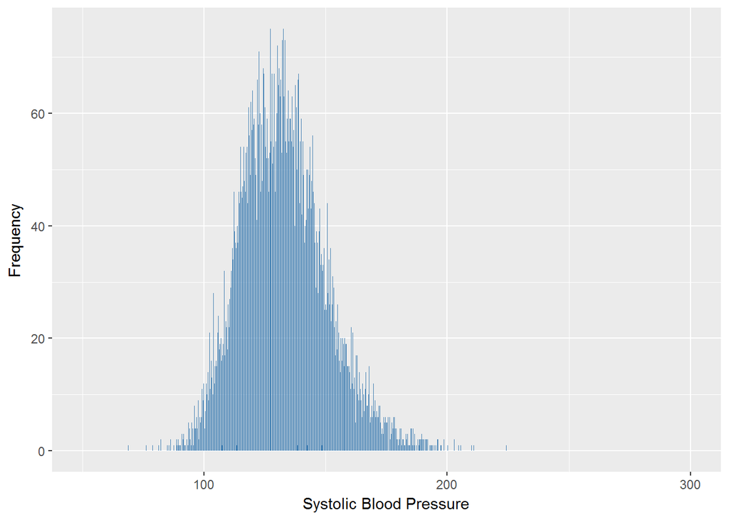

#### 2.1.6.4 Validation

### 2.1.7 Wave 7

There is no variable.

# 3 Quality estimation